# JSC370H1 - Assignment 4

# Part 1: High performance computing

### 1.

```r
# Sum of each row
fun1 <- function(mat) {
  n <- nrow(mat)
  ans <- double(n)
  for (i in 1:n) {
    ans[i] <- sum(mat[i, ])
  }
  ans
}

fun1alt <- function(mat) {
  rowSums(mat)
}

# Cumulative sum by row
fun2 <- function(mat) {
  n <- nrow(mat)
  k <- ncol(mat)
  ans <- mat
  for (i in 1:n) {
    for (j in 2:k) {
      ans[i,j] <- mat[i, j] + ans[i, j - 1]
    }
  }
  ans
}

fun2alt <- function(mat) {
  t(apply(mat, 1, cumsum))
}

set.seed(2315)
dat <- matrix(rnorm(200 * 100), nrow = 200)

microbenchmark::microbenchmark(
  fun1(dat),
  fun1alt(dat), unit = "relative", check = "equivalent"
)
```

```
## Unit: relative
##          expr      min      lq     mean   median       uq       max neval cld
##     fun1(dat) 3.768844 4.29559 4.038676 5.121823 5.243384 0.3193577   100  a
##  fun1alt(dat) 1.000000 1.00000 1.000000 1.000000 1.000000 1.0000000   100   b
```

```r
microbenchmark::microbenchmark(
  fun2(dat),
  fun2alt(dat), unit = "relative", check = "equivalent"
)
```

```
## Unit: relative
##          expr      min       lq     mean   median       uq      max neval cld
##     fun2(dat) 4.466874 4.305692 3.462832 4.143143 3.196452 1.512091   100  a
##  fun2alt(dat) 1.000000 1.000000 1.000000 1.000000 1.000000 1.000000   100   b
```

I used `rowSums` and `cumsum` for the alternative functions, which are around 3 to 4 times faster compared to their respective original functions.

### 2.

```r
sim_pi <- function(n = 1000, i = NULL) {
  p <- matrix(runif(n * 2), ncol = 2)
  mean(rowSums(p^2) < 1) * 4
}

# Serial computing
set.seed(1231)
system.time({
  ans <- unlist(lapply(1:4000, sim_pi, n = 10000))
  print(mean(ans))
})
```

```
## [1] 3.14124
```

```
##    user  system elapsed
##   1.535   0.368   1.903
```

```r
# Parallel computing
set.seed(1231)
system.time({
  cl <- makePSOCKcluster(detectCores())
  clusterSetRNGStream(cl, 1231)
  clusterExport(cl, varlist = c("sim_pi"), envir = environment())
  ans <- unlist(parLapply(cl, 1:4000, function(i) {
    sim_pi(n = 10000)
  }))
  stopCluster(cl)
  print(mean(ans))
})
```

```
## [1] 3.141144
```

```
##    user  system elapsed
##   0.018   0.001   1.542
```

# Part 2: Machine learning

```r
data <- read_csv("https://raw.githubusercontent.com/JSC370/JSC370-2024/main/data/hitters/hitters.csv")

# Splitting the data into training and testing sets
set.seed(100)
train <- sample(1:nrow(data), round(0.7 * nrow(data)))
data_train <- data[train,]
data_test <- data[-train,]
```

### 1.

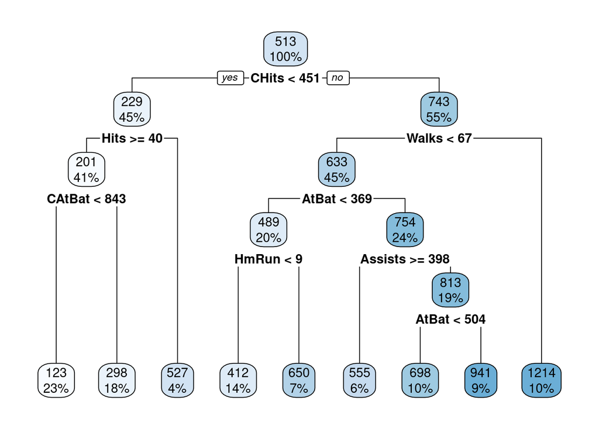

```r
# Regression tree
regression_tree <- rpart(Salary ~ ., method = 'anova', data = data_train)

# Pruning the tree
optimalcp <- regression_tree$cptable[which.min(regression_tree$cptable[, "xerror"]), "CP"]
regression_tree_pruned <- prune(regression_tree, cp = optimalcp)

# Plotting both trees
rpart.plot(regression_tree)
```

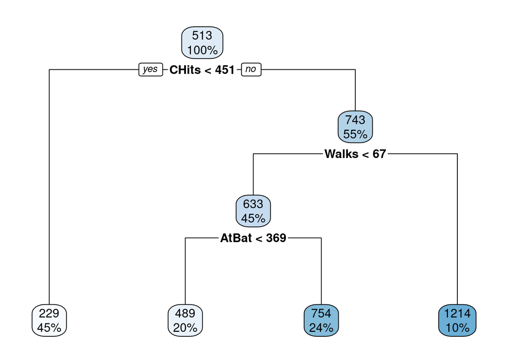

```r
rpart.plot(regression_tree_pruned)
```

The above plots show that the pruned tree is less complex than the initial regression tree, with 3 splits for the former compared to the 8 splits for the latter. The fact that the variables `CHits`, `Walks`, and `AtBat` determine the splits of the pruned tree, which has the optimal complexity parameter, suggests that they are relatively important variables.

### 2.

```r
set.seed(100)

# Bagging
bag <- randomForest(Salary ~ ., data = data_train, mtry = ncol(data_train) - 1, na.action = na.omit)

# Creating data frame for variable importance
imp <- as.data.frame(varImpPlot(bag))
```

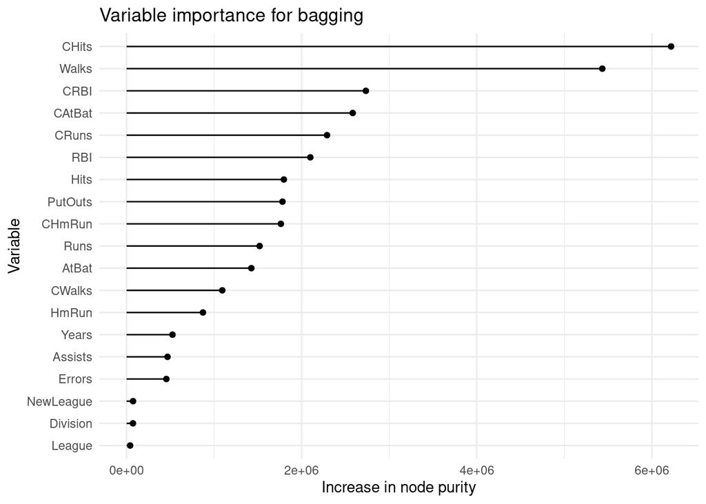

```r
imp$var_names <- rownames(imp)

# Plotting variable importance for bagging
imp |> ggplot(aes(x = reorder(var_names, IncNodePurity), y = IncNodePurity)) +
  geom_point() +
  geom_segment(aes(x = var_names, xend = var_names, y = 0, yend = IncNodePurity)) +
  labs(title = "Variable importance for bagging", x = "Variable", y = "Increase in node purity") +
  coord_flip()
```

The above plot shows that for bagging, the two most important variables are `CHits` and `Walks`, with most of the other variables being significantly less important than to them (as measured by their increases in node purity). This is somewhat consistent with the pruned regression tree, which uses `CHits` and `Walks` on two of its splits, indicating the importance of the two variables.

### 3.

```r
set.seed(100)

# Random forest
rf <- randomForest(Salary ~ ., data = data_train, na.action = na.omit)

# Creating data frame for variable importance for random forest
imp <- as.data.frame(varImpPlot(rf))
```

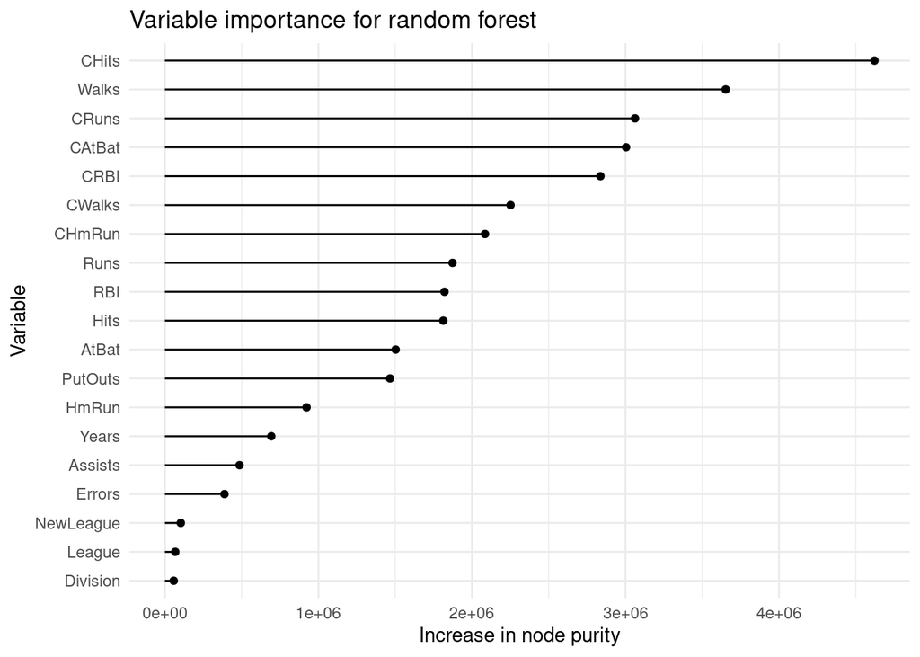

```r
imp$var_names <- rownames(imp)

# Plotting variable importance for random forest
imp |> ggplot(aes(x = reorder(var_names, IncNodePurity), y = IncNodePurity)) +
  geom_point() +
  geom_segment(aes(x = var_names, xend = var_names, y = 0, yend = IncNodePurity)) +
  labs(title = "Variable importance for random forest", x = "Variable", y = "Increase in node purity") +
  coord_flip()
```

The above plot shows that for random forest, the two most important variables are `CHits` and `Walks`, which is consistent with bagging. The difference compared to bagging is that here, there is a larger difference between the increases in node purity for `CHits` and `Walks`, while there is a smaller difference between the increases in node purity for `Walks` and the next most important variable. In addition, the order of the rest of the variables is different as well.

### 4.

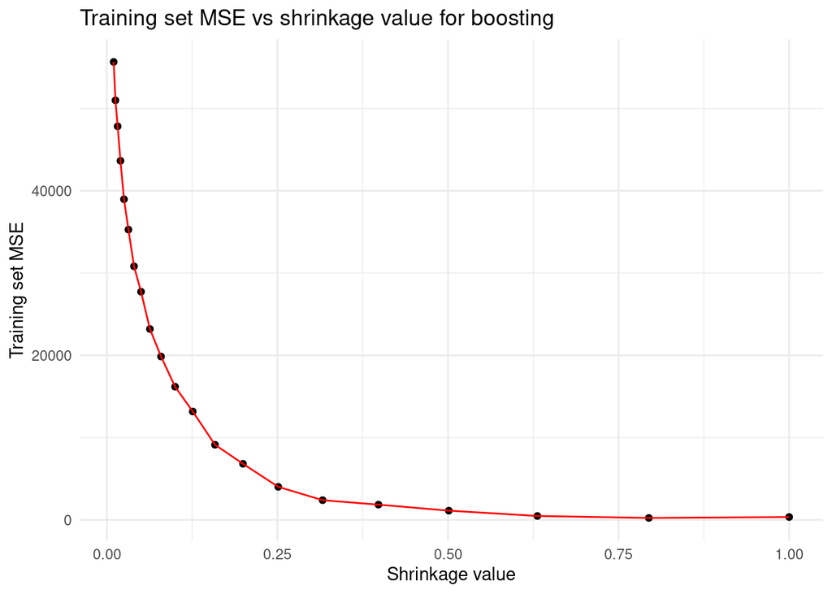

```r
set.seed(100)

# Preparing training set for boosting
boost_train <- na.omit(data_train)
boost_train$League <- as.factor(boost_train$League)
boost_train$Division <- as.factor(boost_train$Division)
boost_train$NewLeague <- as.factor(boost_train$NewLeague)

# Preparing lists for plotting
shrinkage <- 10^seq(-2, 0, 0.1)
train_error <- rep(NA, length(shrinkage))

# Iterating over shrinkage values
for (i in 1:length(shrinkage)) {
  boost <- gbm(Salary ~ ., data = boost_train,
               distribution = 'gaussian', n.trees = 1000,
               shrinkage = shrinkage[i])
  boost_pred <- predict(boost, boost_train, n.trees = 1000)
  train_error[i] <- mean((boost_pred - boost_train$Salary)^2)
}

# Plotting training set MSE vs shrinkage value
ggplot(aes(x = shrinkage, y = train_error), data = NULL) +
  geom_point() +
  geom_line(color = "red") +
  labs(title = "Training set MSE vs shrinkage value for boosting",
       x = "Shrinkage value", y = "Training set MSE")
```

The above plot shows that for boosting, training set MSE decreases as shrinkage value increases.

```r
# Creating data frame for variable importance for boosting
imp <- as.data.frame(summary.gbm(boost))
```

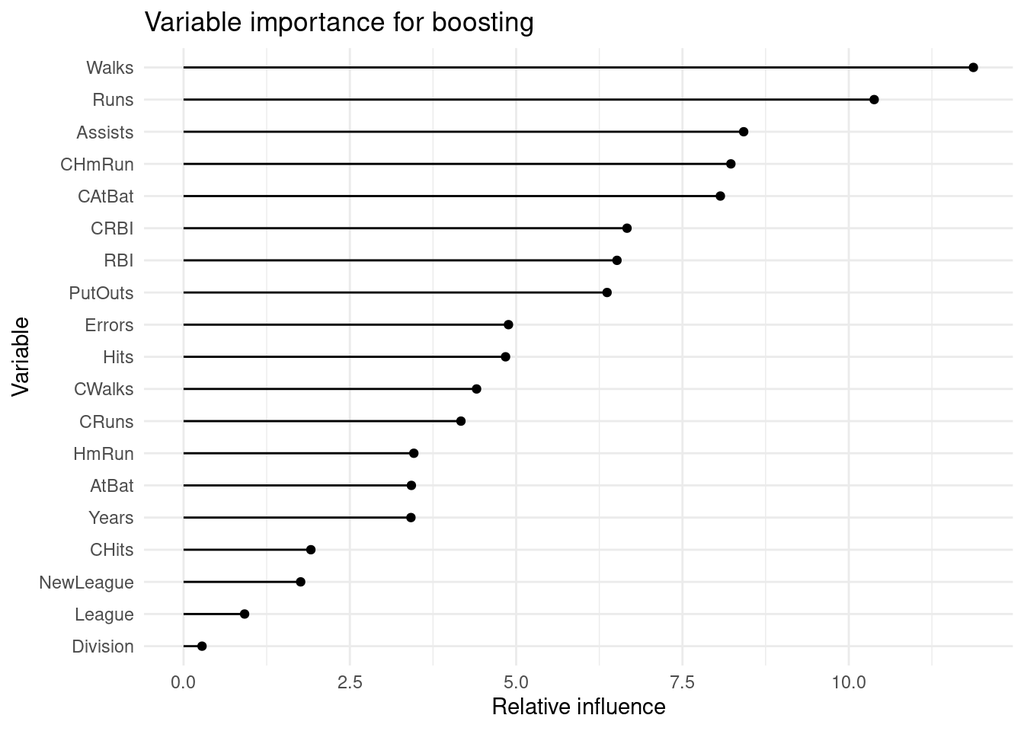

```r
# Plotting variable importance for boosting
imp |> ggplot(aes(x = reorder(var, rel.inf), y = rel.inf)) +
  geom_point() +
  geom_segment(aes(x = var, xend = var, y = 0, yend = rel.inf)) +
  labs(title = "Variable importance for boosting", x = "Variable", y = "Relative influence") +
  coord_flip()
```

The above plot shows that for boosting (with $\lambda = 1$), the most important variable is `Walks`, which is the second most important variable for bagging and random forest. However, `CHits`, which is the most important variable for bagging and random forest, has the fourth smallest importance for boosting, and the order of the rest of the variables is different as well. This discrepancy might be due to the differences in the models and the metric used for measuring importance in GBMs (which is relative influence instead of increase in node purity).

### 5.

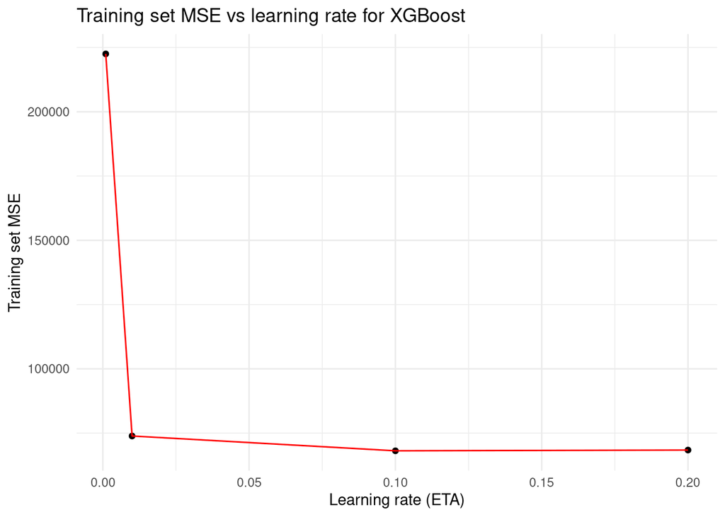

```r
# Creating grid of parameters for XGBoost
tune_grid <- expand.grid(max_depth = c(1, 3, 5, 7),
                         nrounds = (1:10) * 50,
                         eta = c(0.001, 0.01, 0.1, 0.2),
                         gamma = 0,
                         subsample = 1,
                         min_child_weight = 1,
                         colsample_bytree = 0.6)

# XGBoost
xgb <- caret::train(Salary ~ ., data = boost_train, method = 'xgbTree',
                    trControl = trainControl(method = "cv", number = 10, search = "grid"),
                    tuneGrid = tune_grid, verbosity = 0)

xgb$results |>
  select(eta, RMSE) |>
  group_by(eta) |>
  summarize(MSE = min(RMSE)^2) |>
  ggplot(aes(x = eta, y = MSE)) +
  geom_point() +
  geom_line(color = "red") +
  labs(title = "Training set MSE vs learning rate for XGBoost",
       x = "Learning rate (ETA)", y = "Training set MSE")
```

For the above plot, I selected the minimum MSE for each `max_depth`, resulting in one MSE value for every learning rate (which is ETA or the shrinkage rate). Similar to boosting, the plot shows that for XGBoost, training set MSE decreases as the learning rate increases. The decrease is most significant between learning rates of 0.001 and 0.01.

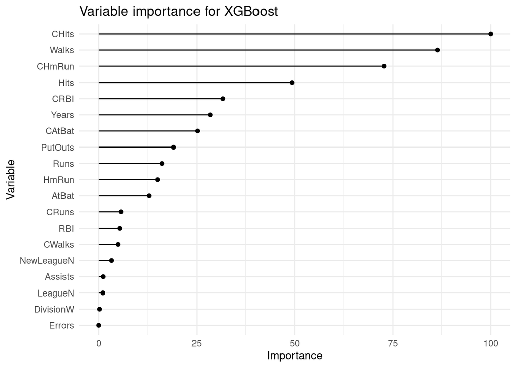

```r
# Creating data frame for variable importance for XGBoost
imp <- varImp(xgb)$importance
imp$var_names <- rownames(imp)

# Plotting variable importance for XGBoost
imp |> ggplot(aes(x = reorder(var_names, Overall), y = Overall)) +
  geom_point() +
  geom_segment(aes(x = var_names, xend = var_names, y = 0, yend = Overall)) +
  labs(title = "Variable importance for XGBoost", x = "Variable", y = "Importance") +
  coord_flip()
```

For XGBoost, the two most important variables are `CHits` and `Walks`, which is consistent with bagging and random forest, and to a lesser degree the pruned regression tree.

### 6.

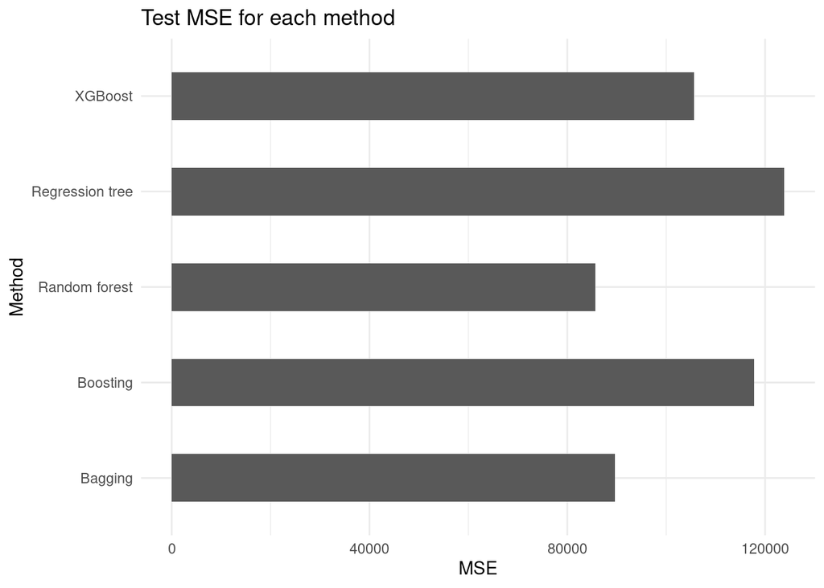

```r
# Removing NA's from test set
data_test <- na.omit(data_test)

# Regression tree MSE
regression_pred <- predict(regression_tree_pruned, data_test)
regression_MSE <- mean((regression_pred - data_test$Salary)^2)

# Bagging MSE
bag_pred <- predict(bag, data_test)
bag_MSE <- mean((bag_pred - data_test$Salary)^2)

# Random forest MSE
rf_pred <- predict(rf, data_test)
rf_MSE <- mean((rf_pred - data_test$Salary)^2)

# Boosting MSE
test_error <- rep(NA, length(shrinkage))
for (i in 1:length(shrinkage)) {
  boost <- gbm(Salary ~ ., data = boost_train,
               distribution = 'gaussian', n.trees = 1000,
               shrinkage = shrinkage[i])
  boost_pred <- predict(boost, data_test, n.trees = 1000)
  test_error[i] <- mean((boost_pred - data_test$Salary)^2)
}
boost_MSE <- mean(test_error)

# XGBoost MSE
xgb_pred <- predict(xgb, data_test)
xgb_MSE <- mean((xgb_pred - data_test$Salary)^2)

data.frame(Method = c("Regression tree", "Bagging", "Random forest", "Boosting", "XGBoost"),
           MSE = c(regression_MSE, bag_MSE, rf_MSE, boost_MSE, xgb_MSE)) |>
  ggplot(aes(x = Method, y = MSE)) +
  geom_bar(stat = 'identity', width = 0.5) +
  labs(title = "Test MSE for each method") +
  coord_flip()
```

The plot above shows that random forest has the lowest MSE while the pruned regression tree has the highest. Thus, the best-performing approach is random forest. Interestingly, while XGBoost has a lower MSE than regular boosting, it does not have the lowest MSE. This could be because the hyperparameters have not been tuned sufficiently or that XGBoost is overly complex for the data.

### 7.

To summarize, the two most importance variables for bagging, random forest, and XGBoost are `CHits` and `Walks`. For boosting, the most important variable is `Walks`, while `CHits` has relatively little importance. Since `CHits` and `Walks` have high importance scores for most or all of questions 2 to 5, we can be confident that they are important for predicting players’ salaries. Other than this, there are minor differences for the results of each question, such as the order of the rest of the variables by importance.